# SeqMonk Vistory Report

## pmQC H3K27ac

Probes Quantitated

Read Count Quantitation using All Reads correcting for total count per million reads log transformed

## Project Summary

### Basic Project Info

| Parameter | Value |
| --- | --- |
| Project Name | pluripotency_exit_TET_K27ac_K27m_K4m_input.smk |
| Vistory Name | pluripotency_exit_TET_K27ac.smv |
| Genome | Mus musculus GRCm38_v95 |
| SeqMonk Version | 1.45.3.devel |

### Data Sets

| Name | File Name | Reads | Import Options |
| --- | --- | --- | --- |
| TET_KO_2i_H3K27me3_rep1 | Reimported from P31C7 | 51535042 | Visible stores parser Remove DuplicatesNo Extend by 1 |
| TET_KO_2i_H3K27me3_rep2 | Reimported from P32C8 | 28576150 | Visible stores parser Remove DuplicatesNo Extend by 1 |
| TET_KO_2i_H3K27me3_rep3 | Reimported from P33C9 | 64006510 | Visible stores parser Remove DuplicatesNo Extend by 1 |
| TET_KO_2i_H3K4me3_rep1 | Reimported from P43D7 | 25925068 | Visible stores parser Remove DuplicatesNo Extend by 1 |
| TET_KO_2i_H3K4me3_rep2 | Reimported from P44D8 | 50237136 | Visible stores parser Remove DuplicatesNo Extend by 1 |
| TET_KO_2i_H3K4me3_rep3 | Reimported from P45D9 | 42659401 | Visible stores parser Remove DuplicatesNo Extend by 1 |
| TET_KO_2i_HK27Ac_rep1 | Reimported from P7A7 | 28946222 | Visible stores parser Remove DuplicatesNo Extend by 1 |
| TET_KO_2i_HK27Ac_rep2 | Reimported from P8A8 | 21936581 | Visible stores parser Remove DuplicatesNo Extend by 1 |
| TET_KO_2i_HK27Ac_rep3 | Reimported from P9A9 | 34319165 | Visible stores parser Remove DuplicatesNo Extend by 1 |
| TET_KO_2i_Input_(from_K27Ac)_rep1 | Reimported from P19B7 | 21650956 | Visible stores parser Remove DuplicatesNo Extend by 1 |
| TET_KO_2i_Input_(from_K27Ac)_rep2 | Reimported from P20B8 | 26095786 | Visible stores parser Remove DuplicatesNo Extend by 1 |
| TET_KO_2i_Input_(from_K27Ac)_rep3 | Reimported from P21B9 | 24001847 | Visible stores parser Remove DuplicatesNo Extend by 1 |
| TET_KO_EpiLC_H3K27me3_rep1 | Reimported from P34C10 | 38284173 | Visible stores parser Remove DuplicatesNo Extend by 1 |
| TET_KO_EpiLC_H3K27me3_rep2 | Reimported from P35C11 | 44174743 | Visible stores parser Remove DuplicatesNo Extend by 1 |
| TET_KO_EpiLC_H3K27me3_rep3 | Reimported from P36C12 | 39041869 | Visible stores parser Remove DuplicatesNo Extend by 1 |
| TET_KO_EpiLC_H3K4me3_rep1 | Reimported from P46D10 | 67322561 | Visible stores parser Remove DuplicatesNo Extend by 1 |
| TET_KO_EpiLC_H3K4me3_rep2 | Reimported from P47D11 | 55988267 | Visible stores parser Remove DuplicatesNo Extend by 1 |
| TET_KO_EpiLC_H3K4me3_rep3 | Reimported from P48D12 | 49757273 | Visible stores parser Remove DuplicatesNo Extend by 1 |
| TET_KO_EpiLC_HK27Ac_rep1 | Reimported from P10A10 | 22830911 | Visible stores parser Remove DuplicatesNo Extend by 1 |
| TET_KO_EpiLC_HK27Ac_rep2 | Reimported from P11A11 | 40926263 | Visible stores parser Remove DuplicatesNo Extend by 1 |
| TET_KO_EpiLC_HK27Ac_rep3 | Reimported from P12A12 | 43349875 | Visible stores parser Remove DuplicatesNo Extend by 1 |
| TET_KO_EpiLC_Input_(from_K27Ac)_rep1 | Reimported from P22B10 | 29012252 | Visible stores parser Remove DuplicatesNo Extend by 1 |
| TET_KO_EpiLC_Input_(from_K27Ac)_rep2 | Reimported from P23B11 | 30442213 | Visible stores parser Remove DuplicatesNo Extend by 1 |
| TET_KO_EpiLC_Input_(from_K27Ac)_rep3 | Reimported from P24B12 | 27902684 | Visible stores parser Remove DuplicatesNo Extend by 1 |
| TET_WT_2i_H3K27me3_rep1 | Reimported from P25C1 | 31626018 | Visible stores parser Remove DuplicatesNo Extend by 1 |
| TET_WT_2i_H3K27me3_rep2 | Reimported from P26C2 | 33396554 | Visible stores parser Remove DuplicatesNo Extend by 1 |
| TET_WT_2i_H3K27me3_rep3 | Reimported from P27C3 | 36330115 | Visible stores parser Remove DuplicatesNo Extend by 1 |
| TET_WT_2i_H3K4me3_rep1 | Reimported from P37D1 | 42594375 | Visible stores parser Remove DuplicatesNo Extend by 1 |
| TET_WT_2i_H3K4me3_rep2 | Reimported from P38D2 | 63063857 | Visible stores parser Remove DuplicatesNo Extend by 1 |
| TET_WT_2i_H3K4me3_rep3 | Reimported from P39D3 | 49574502 | Visible stores parser Remove DuplicatesNo Extend by 1 |
| TET_WT_2i_HK27Ac_rep1 | Reimported from P1A1 | 50523674 | Visible stores parser Remove DuplicatesNo Extend by 1 |
| TET_WT_2i_HK27Ac_rep2 | Reimported from P2A2 | 78712619 | Visible stores parser Remove DuplicatesNo Extend by 1 |
| TET_WT_2i_HK27Ac_rep3 | Reimported from P3A3 | 34073413 | Visible stores parser Remove DuplicatesNo Extend by 1 |
| TET_WT_2i_Input_(from_K27Ac)_rep1 | Reimported from P13B1 | 36168015 | Visible stores parser Remove DuplicatesNo Extend by 1 |
| TET_WT_2i_Input_(from_K27Ac)_rep2 | Reimported from P14B2 | 32646981 | Visible stores parser Remove DuplicatesNo Extend by 1 |
| TET_WT_2i_Input_(from_K27Ac)_rep3 | Reimported from P15B3 | 34005482 | Visible stores parser Remove DuplicatesNo Extend by 1 |
| TET_WT_EpiLC_H3K27me3_rep1 | Reimported from P28C4 | 30199713 | Visible stores parser Remove DuplicatesNo Extend by 1 |
| TET_WT_EpiLC_H3K27me3_rep2 | Reimported from P29C5 | 36210124 | Visible stores parser Remove DuplicatesNo Extend by 1 |
| TET_WT_EpiLC_H3K27me3_rep3 | Reimported from P30C6 | 28020688 | Visible stores parser Remove DuplicatesNo Extend by 1 |
| TET_WT_EpiLC_H3K4me3_rep1 | Reimported from P40D4 | 46075458 | Visible stores parser Remove DuplicatesNo Extend by 1 |
| TET_WT_EpiLC_H3K4me3_rep2 | Reimported from P41D5 | 36302942 | Visible stores parser Remove DuplicatesNo Extend by 1 |
| TET_WT_EpiLC_H3K4me3_rep3 | Reimported from P42D6 | 30522716 | Visible stores parser Remove DuplicatesNo Extend by 1 |
| TET_WT_EpiLC_HK27Ac_rep1 | Reimported from P4A4 | 36577127 | Visible stores parser Remove DuplicatesNo Extend by 1 |
| TET_WT_EpiLC_HK27Ac_rep2 | Reimported from P5A5 | 31689099 | Visible stores parser Remove DuplicatesNo Extend by 1 |
| TET_WT_EpiLC_HK27Ac_rep3 | Reimported from P6A6 | 34663656 | Visible stores parser Remove DuplicatesNo Extend by 1 |
| TET_WT_EpiLC_Input_(from_K27Ac)_rep1 | Reimported from P16B4 | 35404322 | Visible stores parser Remove DuplicatesNo Extend by 1 |
| TET_WT_EpiLC_Input_(from_K27Ac)_rep2 | Reimported from P17B5 | 29734189 | Visible stores parser Remove DuplicatesNo Extend by 1 |
| TET_WT_EpiLC_Input_(from_K27Ac)_rep3 | Reimported from P18B6 | 28891553 | Visible stores parser Remove DuplicatesNo Extend by 1 |

### Replicate Sets

| TET_KO_2i_H3K27me3 | TET_KO_2i_H3K4me3 | TET_KO_2i_HK27Ac | TET_KO_2i_Input_(from_K27Ac) | TET_KO_EpiLC_H3K27me3 | TET_KO_EpiLC_H3K4me3 | TET_KO_EpiLC_HK27Ac | TET_KO_EpiLC_Input_(from_K27Ac) | TET_WT_2i_H3K27me3 | TET_WT_2i_H3K4me3 | TET_WT_2i_HK27Ac | TET_WT_2i_Input_(from_K27Ac) | TET_WT_EpiLC_H3K27me3 | TET_WT_EpiLC_H3K4me3 | TET_WT_EpiLC_HK27Ac | TET_WT_EpiLC_Input_(from_K27Ac) |
| --- | --- | --- | --- | --- | --- | --- | --- | --- | --- | --- | --- | --- | --- | --- | --- |
| TET_KO_2i_H3K27me3_rep1 | TET_KO_2i_H3K4me3_rep1 | TET_KO_2i_HK27Ac_rep1 | TET_KO_2i_Input_(from_K27Ac)_rep1 | TET_KO_EpiLC_H3K27me3_rep1 | TET_KO_EpiLC_H3K4me3_rep1 | TET_KO_EpiLC_HK27Ac_rep1 | TET_KO_EpiLC_Input_(from_K27Ac)_rep1 | TET_WT_2i_H3K27me3_rep1 | TET_WT_2i_H3K4me3_rep1 | TET_WT_2i_HK27Ac_rep1 | TET_WT_2i_Input_(from_K27Ac)_rep1 | TET_WT_EpiLC_H3K27me3_rep1 | TET_WT_EpiLC_H3K4me3_rep1 | TET_WT_EpiLC_HK27Ac_rep1 | TET_WT_EpiLC_Input_(from_K27Ac)_rep1 |
| TET_KO_2i_H3K27me3_rep2 | TET_KO_2i_H3K4me3_rep2 | TET_KO_2i_HK27Ac_rep2 | TET_KO_2i_Input_(from_K27Ac)_rep2 | TET_KO_EpiLC_H3K27me3_rep2 | TET_KO_EpiLC_H3K4me3_rep2 | TET_KO_EpiLC_HK27Ac_rep2 | TET_KO_EpiLC_Input_(from_K27Ac)_rep2 | TET_WT_2i_H3K27me3_rep2 | TET_WT_2i_H3K4me3_rep2 | TET_WT_2i_HK27Ac_rep2 | TET_WT_2i_Input_(from_K27Ac)_rep2 | TET_WT_EpiLC_H3K27me3_rep2 | TET_WT_EpiLC_H3K4me3_rep2 | TET_WT_EpiLC_HK27Ac_rep2 | TET_WT_EpiLC_Input_(from_K27Ac)_rep2 |
| TET_KO_2i_H3K27me3_rep3 | TET_KO_2i_H3K4me3_rep3 | TET_KO_2i_HK27Ac_rep3 | TET_KO_2i_Input_(from_K27Ac)_rep3 | TET_KO_EpiLC_H3K27me3_rep3 | TET_KO_EpiLC_H3K4me3_rep3 | TET_KO_EpiLC_HK27Ac_rep3 | TET_KO_EpiLC_Input_(from_K27Ac)_rep3 | TET_WT_2i_H3K27me3_rep3 | TET_WT_2i_H3K4me3_rep3 | TET_WT_2i_HK27Ac_rep3 | TET_WT_2i_Input_(from_K27Ac)_rep3 | TET_WT_EpiLC_H3K27me3_rep3 | TET_WT_EpiLC_H3K4me3_rep3 | TET_WT_EpiLC_HK27Ac_rep3 | TET_WT_EpiLC_Input_(from_K27Ac)_rep3 |

### Quantitation

| Name | Parent | Probes | Description | Comments |
| --- | --- | --- | --- | --- |
| All Probes |  | 1362779 | Running windows of size 2000 with step size 2000. Quantitated with Read Count Quantitation using All Reads correcting for total count per million reads log transformed |  |
| Value between 100 and 200 | All Probes | 2 | [Probe Values Filter] Filter on probes in All Probes where exactly 12 of TET_KO_2i_Input_(from_K27Ac)_rep1 , TET_KO_2i_Input_(from_K27Ac)_rep2 , TET_KO_2i_Input_(from_K27Ac)_rep3 , TET_KO_EpiLC_Input_… |  |
| Value above 5 | All Probes | 81 | [Probe Values Filter] Filter on probes in All Probes where exactly 12 of TET_KO_2i_Input_(from_K27Ac)_rep1 , TET_KO_2i_Input_(from_K27Ac)_rep2 , TET_KO_2i_Input_(from_K27Ac)_rep3 , TET_KO_EpiLC_Input_… |  |
| Chr MT 1-13055 | All Probes | 6 | [Position Filter] Probes from All Probes which are on chromosome MT on strand All Probes between 1 and 13055 |  |
| Value above 5 OR Chr MT 1-13055 | All Probes | 82 | [Combine Filter] Value above 5 OR Chr MT 1-13055 |  |
| sensible regions | All Probes | 1362697 | [Combine Filter] All Probes BUTNOT Value above 5 OR Chr MT 1-13055 |  |

I then reimported all the datasets and excluded the 'excluded regions'.

I renamed _reimport to _sensible_regions.

I deleted all original datasets to keep the project a managable size.

New Probe Set:1kb tiles (2725549 probes)

Running windows of size 1000 with step size 1000

Replicate Sets Removed

Removed Sets: TET_KO_2i_H3K27me3 TET_KO_2i_H3K4me3 TET_KO_2i_HK27Ac TET_KO_2i_Input_(from_K27Ac) TET_KO_EpiLC_H3K27me3 TET_KO_EpiLC_H3K4me3 TET_KO_EpiLC_HK27Ac TET_KO_EpiLC_Input_(from_K27Ac) TET_WT_2i_H3K27me3 TET_WT_2i_H3K4me3 TET_WT_2i_HK27Ac TET_WT_2i_Input_(from_K27Ac) TET_WT_EpiLC_H3K27me3 TET_WT_EpiLC_H3K4me3 TET_WT_EpiLC_HK27Ac TET_WT_EpiLC_Input_(from_K27Ac)

Probes Quantitated

Read Count Quantitation using All Reads correcting for total count per million reads log transformed

Replicate Set Created

TET_KO_2i_H3K27me3 TET_KO_2i_H3K27me3_rep1_sensible_regions TET_KO_2i_H3K27me3_rep2_sensible_regions TET_KO_2i_H3K27me3_rep3_sensible_regions

Replicate Set Created

TET_KO_2i_H3K4me3 TET_KO_2i_H3K4me3_rep1_sensible_regions TET_KO_2i_H3K4me3_rep2_sensible_regions TET_KO_2i_H3K4me3_rep3_sensible_regions

Replicate Set Created

TET_KO_2i_HK27Ac TET_KO_2i_HK27Ac_rep1_sensible_regions TET_KO_2i_HK27Ac_rep2_sensible_regions TET_KO_2i_HK27Ac_rep3_sensible_regions

Replicate Set Created

TET_KO_2i_Input_(from_K27Ac) TET_KO_2i_Input_(from_K27Ac)_rep1_sensible_regions TET_KO_2i_Input_(from_K27Ac)_rep2_sensible_regions TET_KO_2i_Input_(from_K27Ac)_rep3_sensible_regions

Replicate Set Created

TET_KO_EpiLC_H3K27me3 TET_KO_EpiLC_H3K27me3_rep1_sensible_regions TET_KO_EpiLC_H3K27me3_rep2_sensible_regions TET_KO_EpiLC_H3K27me3_rep3_sensible_regions

Replicate Set Created

TET_KO_EpiLC_H3K4me3 TET_KO_EpiLC_H3K4me3_rep1_sensible_regions TET_KO_EpiLC_H3K4me3_rep2_sensible_regions TET_KO_EpiLC_H3K4me3_rep3_sensible_regions

Replicate Set Created

TET_KO_EpiLC_HK27Ac TET_KO_EpiLC_HK27Ac_rep1_sensible_regions TET_KO_EpiLC_HK27Ac_rep2_sensible_regions TET_KO_EpiLC_HK27Ac_rep3_sensible_regions

Replicate Set Created

TET_KO_EpiLC_Input_(from_K27Ac) TET_KO_EpiLC_Input_(from_K27Ac)_rep1_sensible_regions TET_KO_EpiLC_Input_(from_K27Ac)_rep2_sensible_regions TET_KO_EpiLC_Input_(from_K27Ac)_rep3_sensible_regions

Replicate Set Created

TET_WT_2i_H3K27me3 TET_WT_2i_H3K27me3_rep1_sensible_regions TET_WT_2i_H3K27me3_rep2_sensible_regions TET_WT_2i_H3K27me3_rep3_sensible_regions

Replicate Set Created

TET_WT_2i_H3K4me3 TET_WT_2i_H3K4me3_rep1_sensible_regions TET_WT_2i_H3K4me3_rep2_sensible_regions TET_WT_2i_H3K4me3_rep3_sensible_regions

Replicate Set Created

TET_WT_2i_HK27Ac TET_WT_2i_HK27Ac_rep1_sensible_regions TET_WT_2i_HK27Ac_rep2_sensible_regions TET_WT_2i_HK27Ac_rep3_sensible_regions

Replicate Set Created

TET_WT_2i_Input_(from_K27Ac) TET_WT_2i_Input_(from_K27Ac)_rep1_sensible_regions TET_WT_2i_Input_(from_K27Ac)_rep2_sensible_regions TET_WT_2i_Input_(from_K27Ac)_rep3_sensible_regions

Replicate Set Created

TET_WT_EpiLC_H3K27me3 TET_WT_EpiLC_H3K27me3_rep1_sensible_regions TET_WT_EpiLC_H3K27me3_rep2_sensible_regions TET_WT_EpiLC_H3K27me3_rep3_sensible_regions

Replicate Set Created

TET_WT_EpiLC_H3K4me3 TET_WT_EpiLC_H3K4me3_rep1_sensible_regions TET_WT_EpiLC_H3K4me3_rep2_sensible_regions TET_WT_EpiLC_H3K4me3_rep3_sensible_regions

Replicate Set Created

TET_WT_EpiLC_HK27Ac TET_WT_EpiLC_HK27Ac_rep1_sensible_regions TET_WT_EpiLC_HK27Ac_rep2_sensible_regions TET_WT_EpiLC_HK27Ac_rep3_sensible_regions

Replicate Set Created

TET_WT_EpiLC_Input_(from_K27Ac) TET_WT_EpiLC_Input_(from_K27Ac)_rep1_sensible_regions TET_WT_EpiLC_Input_(from_K27Ac)_rep2_sensible_regions TET_WT_EpiLC_Input_(from_K27Ac)_rep3_sensible_regions

### Cumulative distributions

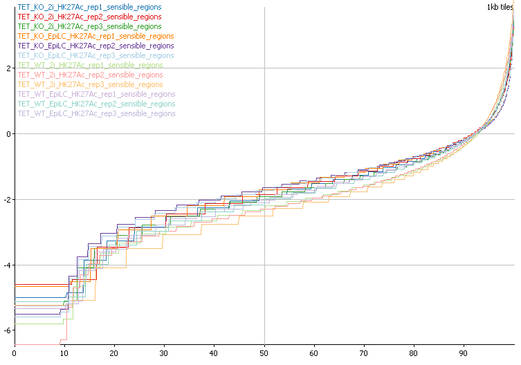

Look very similar between replicates, slightly different between conditions.

### Data store similarity - tree

New Probe List: Value above 0 in at least 1 (318030 probes)

[Probe Values Filter] Filter on probes in 1kb tiles where at least 1 of TET_KO_2i_HK27Ac , TET_KO_EpiLC_HK27Ac , TET_WT_2i_HK27Ac , TET_WT_EpiLC_HK27Ac had a value above 0.0. Quantitation was Read Count Quantitation using All Reads correcting for total count per million reads log transformed

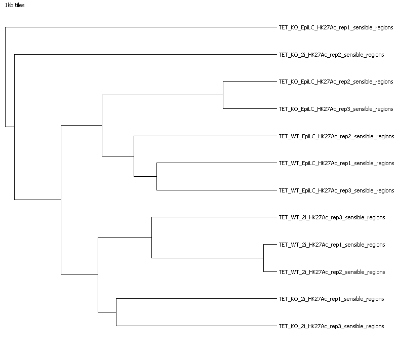

Two of the replicates look different from their mates?

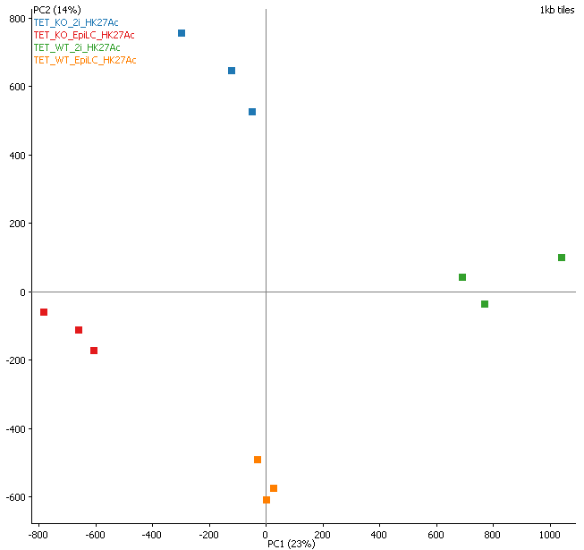

this looks rather more encouraging

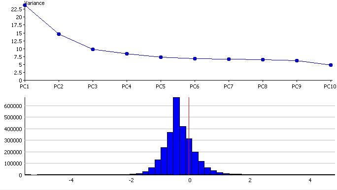

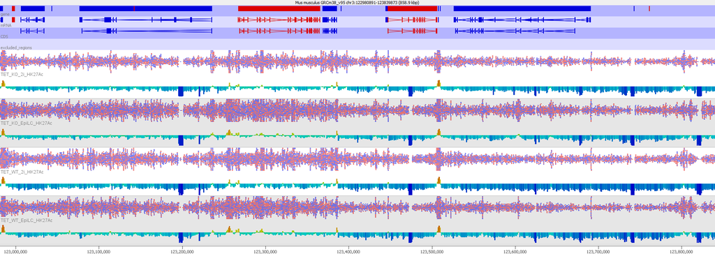

Read locations make sense.